# Laboratorio 1. Series de tiempo

Nina Nájera Marakovits  
Carné 231088  
CC3084 Data Science  
Semestre II 2026

# Objetivo

El objetivo es analizar el ingreso mensual de viajeros internacionales a Guatemala y comparar varios modelos de pronóstico.

Para mantener una comparación válida durante todo el período se utilizan únicamente Turista y Excursionista. Se analiza la serie total, las tres vías de ingreso y las tres regiones con mayor cantidad acumulada de viajeros.

# Preparación

Primero se debe instalar las librerias, están en el requirements.

```
Importing plotly failed. Interactive plots will not work.
```

```
Raíz del proyecto: C:\Users\ninan\OneDrive\Documentos\Escritorio\UVG\VIII SEMESTRE\Data Science\Data_Science
Archivo de datos: C:\Users\ninan\OneDrive\Documentos\Escritorio\UVG\VIII SEMESTRE\Data Science\Data_Science\data\raw\Base_Migracion_2009-2026jun.xlsx
Prophet disponible: True
```

# Carga y limpieza de datos

La fecha se construye con el año y el código del mes. La cantidad de viajeros se convierte a número. Los registros sin fecha o sin cantidad de viajeros no pueden utilizarse en las series y se eliminan únicamente para el análisis temporal.

```
Filas originales: 161,036
Columnas originales: 13
Período: 2009-01 a 2026-06
```

|  | Año | Mes cod | Mes | Vía | Frontera | País | Región | Región dos | Regiones OMT | MCEO | Agrupación Residencia | Tipo de Viajero | Viajero | Fecha |
| --- | --- | --- | --- | --- | --- | --- | --- | --- | --- | --- | --- | --- | --- | --- |
| 0 | 2009 | 1 | Ene | Aérea | 01 La Aurora | Albania | OTROS EUROPEOS | Europa | EUROPA MERIDIONAL | 08 OTROS | Europa | Turista | 1.000 | 2009-01-01 |
| 1 | 2009 | 1 | Ene | Aérea | 01 La Aurora | Alemania | EUROPA | Europa | EUROPA OCCIDENTAL | 04 EUROPA | Europa | Turista | 716.000 | 2009-01-01 |
| 2 | 2009 | 1 | Ene | Aérea | 01 La Aurora | Angola | OTROS PAISES DEL MUNDO | Otros Paises Del Mundo | ÁFRICA CENTRAL | 08 OTROS | Resto del Mundo | Turista | 4.000 | 2009-01-01 |
| 3 | 2009 | 1 | Ene | Aérea | 01 La Aurora | Arabia Saudita | OTROS ORIENTE MEDIO | Oriente Medio | ORIENTE MEDIO | 08 OTROS | Resto del Mundo | Turista | 5.000 | 2009-01-01 |
| 4 | 2009 | 1 | Ene | Aérea | 01 La Aurora | Argelia | OTROS PAISES DEL MUNDO | Otros Paises Del Mundo | ÁFRICA DEL NORTE | 08 OTROS | Resto del Mundo | Turista | 1.000 | 2009-01-01 |

# Análisis de calidad

Se revisan valores faltantes, duplicados y posibles valores atípicos. Los valores atípicos no se eliminan de forma automática porque pueden representar meses, fronteras o mercados con una cantidad realmente alta de viajeros.

|  | Indicador | Valor |
| --- | --- | --- |
| 0 | Filas originales | 161036 |
| 1 | Valores faltantes | 0 |
| 2 | Duplicados exactos | 0 |
| 3 | Registros con cero viajeros | 54 |
| 4 | Posibles atípicos según IQR | 26390 |

```
Valores faltantes por columna
```

|  | Valores faltantes |
| --- | --- |

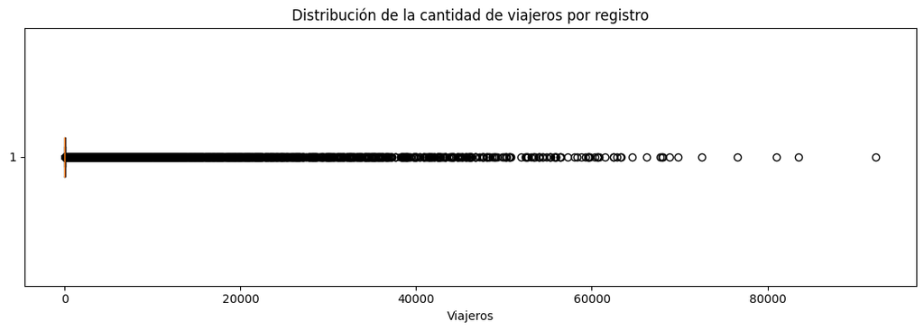

# Selección de registros comparables

La categoría Viajero cambia entre 2022 y 2023. Para evitar una caída causada por el cambio de definición se utilizan Turista y Excursionista durante todo el período.

| Tipo de Viajero | Viajeros |
| --- | --- |
| Turista | 37,642,728.550 |
| Excursionista | 9,069,184.336 |
| Viajero | 4,471,622.207 |
| Cruceristas | 1,104,402.000 |

```
Filas utilizadas: 137,642
Viajeros acumulados: 46,711,913
```

# Análisis exploratorio

Se revisa el comportamiento mensual y anual. También se identifican los países, regiones, vías y fronteras con mayor cantidad acumulada de viajeros.

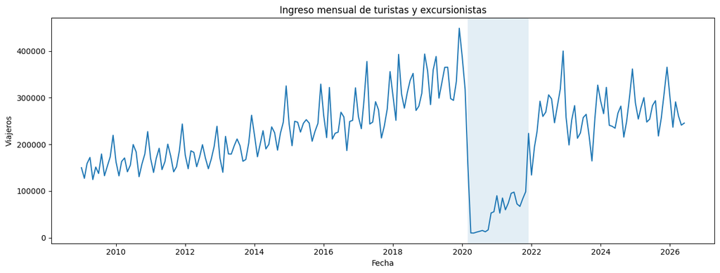

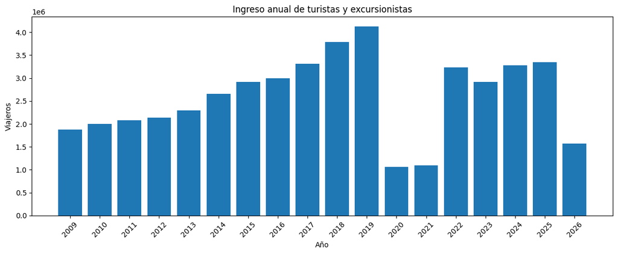

| Fecha | Viajeros |
| --- | --- |
| 2009-01-01 | 1,880,182.852 |
| 2010-01-01 | 2,004,783.999 |
| 2011-01-01 | 2,079,714.603 |
| 2012-01-01 | 2,139,541.481 |
| 2013-01-01 | 2,289,702.752 |
| 2014-01-01 | 2,660,177.317 |
| 2015-01-01 | 2,917,886.040 |
| 2016-01-01 | 2,997,026.744 |
| 2017-01-01 | 3,307,651.287 |
| 2018-01-01 | 3,793,760.857 |
| 2019-01-01 | 4,132,250.602 |
| 2020-01-01 | 1,059,770.432 |
| 2021-01-01 | 1,098,964.379 |
| 2022-01-01 | 3,229,328.600 |
| 2023-01-01 | 2,917,826.811 |
| 2024-01-01 | 3,274,435.995 |
| 2025-01-01 | 3,352,288.658 |
| 2026-01-01 | 1,576,619.476 |

```
Cambio de 2020 frente a 2019: -74.35 por ciento
El año 2026 contiene únicamente datos de enero a junio.
```

```
Países o mercados con más viajeros
```

| País | Viajeros |
| --- | --- |
| El Salvador | 14,079,135.771 |
| Guatemala | 13,870,391.348 |
| Estados Unidos de América | 6,965,679.710 |
| Honduras | 2,520,974.307 |
| México | 1,678,422.551 |
| Belice | 916,101.075 |
| Costa Rica | 860,240.685 |
| Nicaragua | 811,145.393 |
| Colombia | 549,494.686 |
| Canadá | 516,707.890 |

```
Regiones con más viajeros
```

| Región dos | Viajeros |
| --- | --- |
| América Del Centro | 33,283,931.980 |
| América Del Norte | 9,160,810.151 |
| Europa | 2,149,271.065 |
| América Del Sur y el Caribe | 1,413,590.324 |
| Asia | 410,333.513 |
| Oceanía | 135,505.366 |
| Oriente Medio | 133,735.192 |
| Otros Paises Del Mundo | 23,914.295 |
| 0 | 821.000 |

```
Vías de ingreso
```

| Vía | Viajeros |
| --- | --- |
| Terrestre | 27,592,253.333 |
| Aérea | 19,019,418.554 |
| Marítima | 100,241.000 |

```
Fronteras más utilizadas
```

| Frontera | Viajeros |
| --- | --- |
| 01 La Aurora | 18,989,984.615 |
| 07 Valle Nuevo | 10,143,045.315 |
| 09 San Cristóbal | 4,183,631.706 |
| 08 Pedro de Alvarado | 3,764,229.263 |
| 10 La Ermita (Nueva Anguiatú) | 2,587,072.270 |
| 20 Melchor de Mencos | 1,782,864.385 |
| 13 El Cinchado / El Corinto | 1,213,485.141 |
| 11 Agua Caliente | 922,419.528 |
| 12 El Florido | 910,373.467 |
| 15 El Carmen | 852,663.132 |

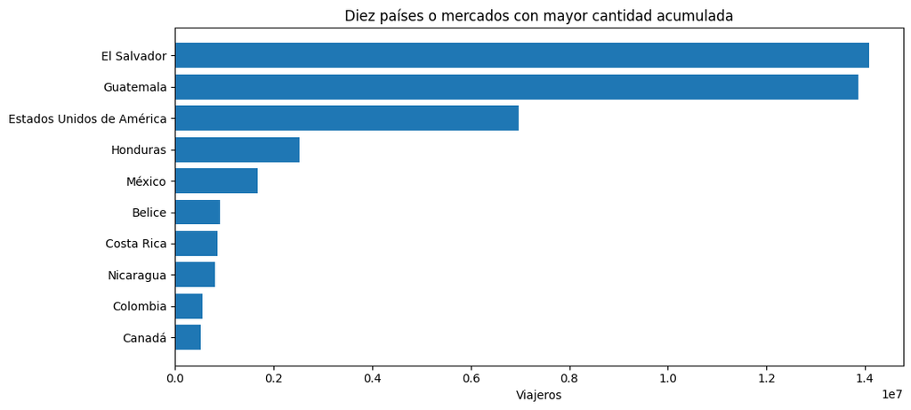

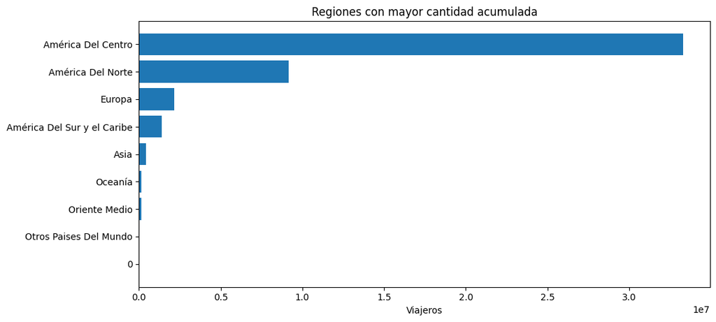

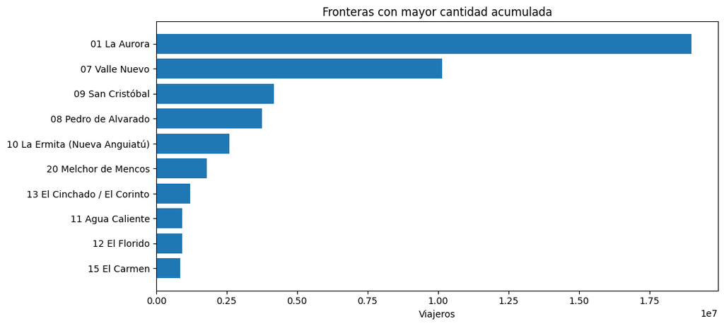

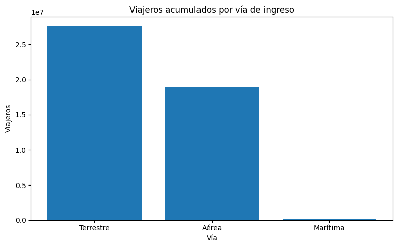

# Estadísticas descriptivas

La media resume el nivel promedio. La desviación estándar y el coeficiente de variación ayudan a comparar la dispersión entre series con tamaños distintos.

|  | Viajero |
| --- | --- |
| count | 137,642.000 |
| mean | 339.373 |
| std | 2,515.138 |
| min | 0.000 |
| 25% | 2.000 |
| 50% | 7.000 |
| 75% | 37.000 |
| 90% | 259.134 |
| 95% | 881.000 |
| 99% | 6,232.770 |
| max | 83,511.000 |

# División de entrenamiento y prueba

La división respeta el orden del tiempo. Los primeros meses forman el conjunto de entrenamiento y los últimos meses forman el conjunto de prueba.

```
Meses totales: 210
Entrenamiento: 147 meses
Inicio de entrenamiento: 2009-01
Fin de entrenamiento: 2021-03
Prueba: 63 meses
Inicio de prueba: 2021-04
Fin de prueba: 2026-06
```

# Construcción de las series

Se construyen siete series mensuales.

1. Total mensual
2. Vía aérea
3. Vía terrestre
4. Vía marítima
5. América Del Centro
6. América Del Norte
7. Europa

Las tres regiones se seleccionan con el total acumulado de todo el período.

| Serie | Inicio | Fin | Frecuencia | Observaciones | Media | Desviación estándar | Coeficiente de variación |
| --- | --- | --- | --- | --- | --- | --- | --- |
| Total | 2009-01 | 2026-06 | Mensual | 210 | 222,437.680 | 84,724.939 | 0.381 |
| Vía Aérea | 2009-01 | 2026-06 | Mensual | 210 | 90,568.660 | 27,855.303 | 0.308 |
| Vía Terrestre | 2009-01 | 2026-06 | Mensual | 210 | 131,391.683 | 60,815.995 | 0.463 |
| Vía Marítima | 2009-01 | 2026-06 | Mensual | 210 | 477.338 | 541.260 | 1.134 |
| Región América Del Centro | 2009-01 | 2026-06 | Mensual | 210 | 158,494.914 | 66,477.133 | 0.419 |
| Región América Del Norte | 2009-01 | 2026-06 | Mensual | 210 | 43,622.905 | 17,881.103 | 0.410 |
| Región Europa | 2009-01 | 2026-06 | Mensual | 210 | 10,234.624 | 4,401.300 | 0.430 |

```
Regiones seleccionadas
América Del Centro
América Del Norte
Europa
```

# Análisis de estacionariedad

Para cada serie se revisa el gráfico, la descomposición, la media móvil, la desviación móvil, la ACF, la PACF y la prueba Dickey Fuller aumentada.

Se usa logaritmo de uno más la serie para reducir cambios grandes en la varianza. Después se revisa si hace falta una diferencia normal y una diferencia estacional de doce meses.

```
==========================================================================================
Total
==========================================================================================
```

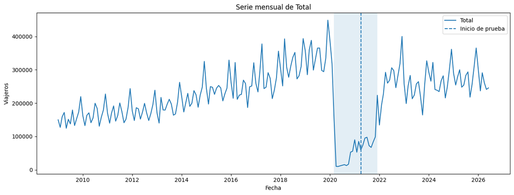

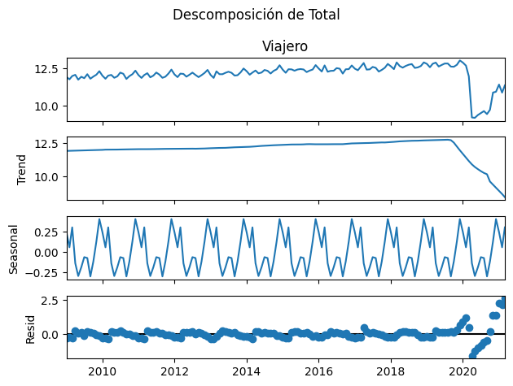

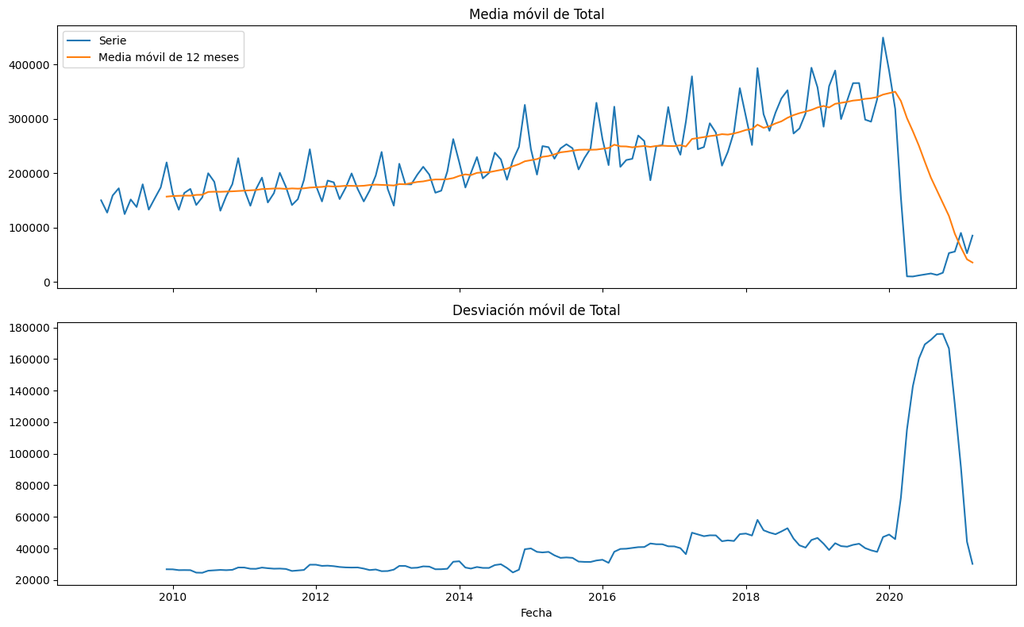

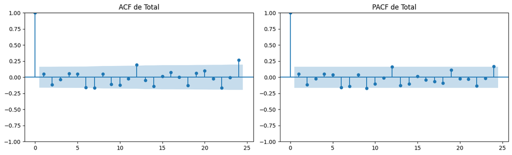

```
Inicio: 2009-01
Fin: 2026-06
Frecuencia: mensual con doce observaciones por año
Fuerza estacional: 0.180
Fuerza de tendencia: 0.532
Lambda Box Cox: 0.991
Valor sugerido de d: 1
Valor sugerido de D: 0
Valor inicial de p: 1
Valor inicial de q: 1
```

|  | Transformación | p valor ADF | Conclusión |
| --- | --- | --- | --- |
| 0 | Original | 0.152 | No estacionaria en media |
| 1 | Logaritmo | 0.116 | No estacionaria en media |
| 2 | Primera diferencia | 0.028 | Estacionaria en media |
| 3 | Diferencia estacional | 0.964 | No estacionaria en media |
| 4 | Primera diferencia y diferencia estacional | 0.000 | Estacionaria en media |

```
La serie no es estacionaria en media y necesita diferenciación.
La estacionalidad es débil y se probarán modelos con menor parte estacional.
==========================================================================================
Vía Aérea
==========================================================================================
```

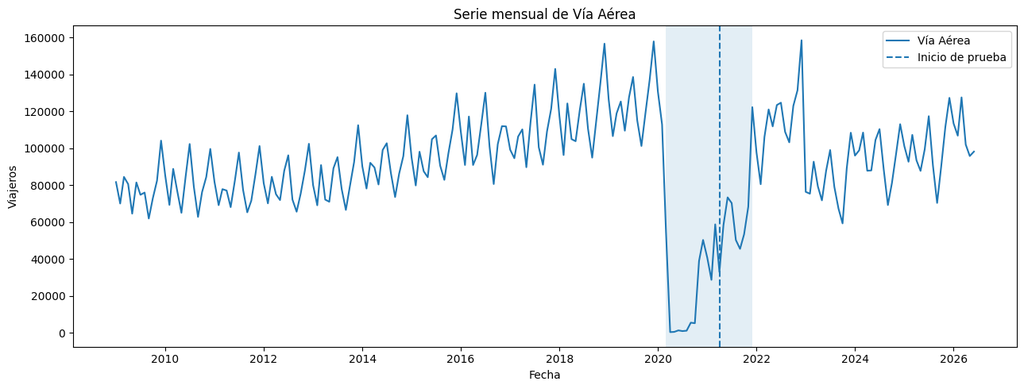

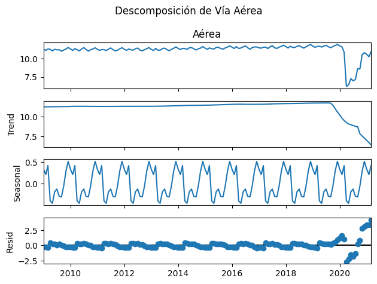

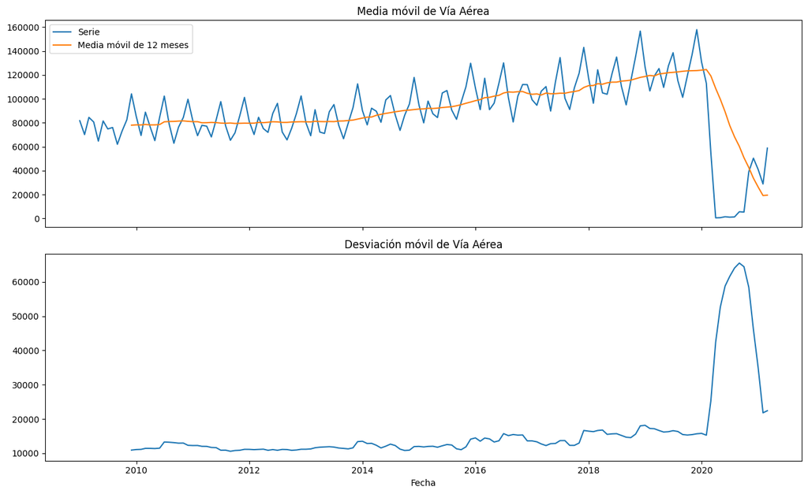

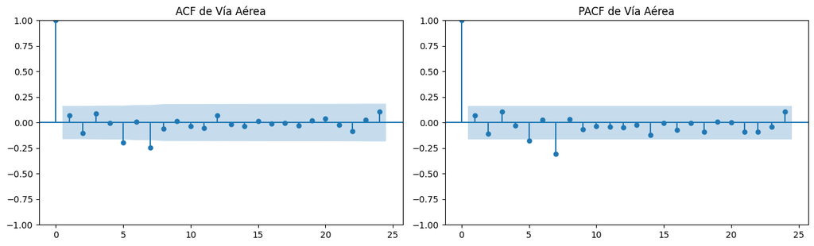

```
Inicio: 2009-01
Fin: 2026-06
Frecuencia: mensual con doce observaciones por año
Fuerza estacional: 0.142
Fuerza de tendencia: 0.259
Lambda Box Cox: 1.257
Valor sugerido de d: 1
Valor sugerido de D: 0
Valor inicial de p: 1
Valor inicial de q: 1
```

|  | Transformación | p valor ADF | Conclusión |
| --- | --- | --- | --- |
| 0 | Original | 0.151 | No estacionaria en media |
| 1 | Logaritmo | 0.273 | No estacionaria en media |
| 2 | Primera diferencia | 0.027 | Estacionaria en media |
| 3 | Diferencia estacional | 0.850 | No estacionaria en media |
| 4 | Primera diferencia y diferencia estacional | 0.000 | Estacionaria en media |

```
La serie no es estacionaria en media y necesita diferenciación.
La estacionalidad es débil y se probarán modelos con menor parte estacional.
==========================================================================================
Vía Terrestre
==========================================================================================
```

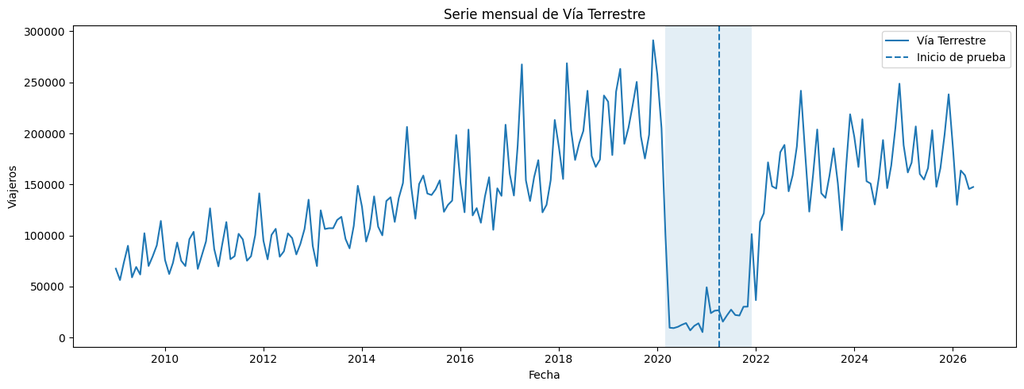

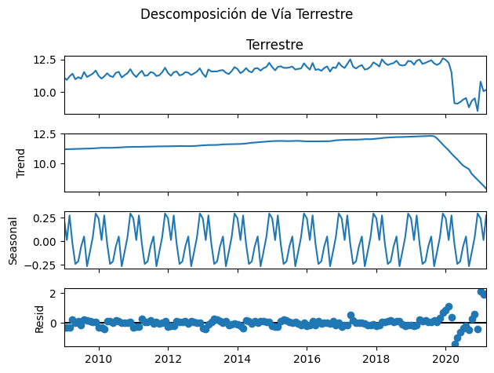

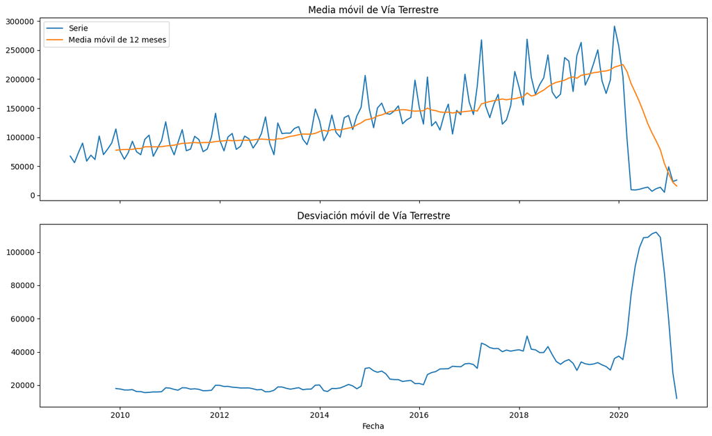

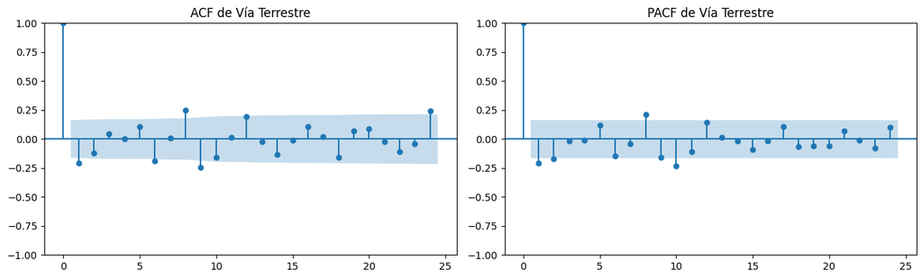

```
Inicio: 2009-01
Fin: 2026-06
Frecuencia: mensual con doce observaciones por año
Fuerza estacional: 0.185
Fuerza de tendencia: 0.714
Lambda Box Cox: 0.761
Valor sugerido de d: 1
Valor sugerido de D: 0
Valor inicial de p: 1
Valor inicial de q: 1
```

|  | Transformación | p valor ADF | Conclusión |
| --- | --- | --- | --- |
| 0 | Original | 0.238 | No estacionaria en media |
| 1 | Logaritmo | 0.277 | No estacionaria en media |
| 2 | Primera diferencia | 0.025 | Estacionaria en media |
| 3 | Diferencia estacional | 0.932 | No estacionaria en media |
| 4 | Primera diferencia y diferencia estacional | 0.000 | Estacionaria en media |

```
La serie no es estacionaria en media y necesita diferenciación.
La estacionalidad es débil y se probarán modelos con menor parte estacional.
==========================================================================================
Vía Marítima
==========================================================================================
```

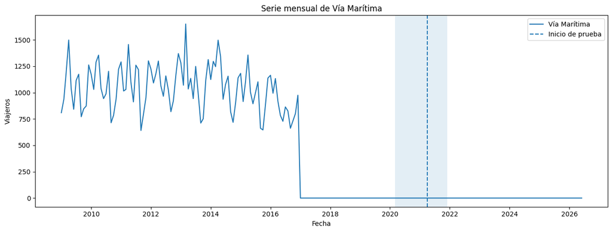

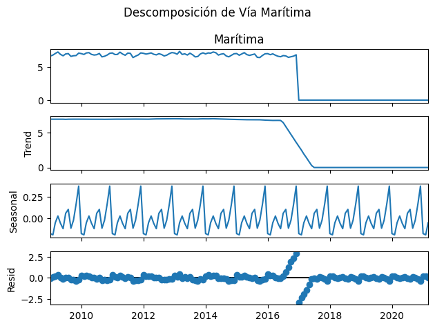

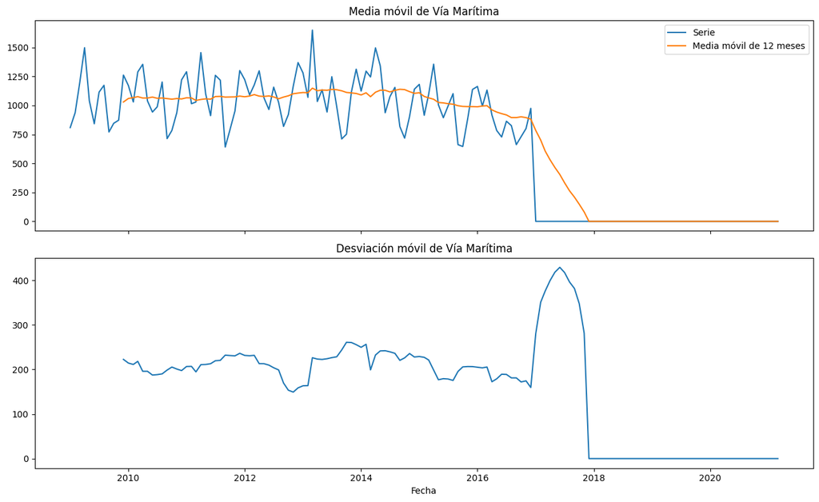

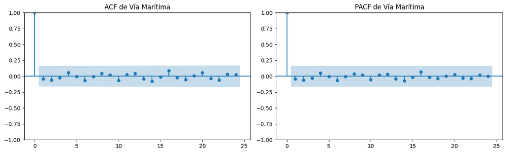

```
Inicio: 2009-01
Fin: 2026-06
Frecuencia: mensual con doce observaciones por año
Fuerza estacional: 0.073
Fuerza de tendencia: 0.972
Lambda Box Cox: 0.269
Valor sugerido de d: 1
Valor sugerido de D: 0
Valor inicial de p: 1
Valor inicial de q: 1
```

|  | Transformación | p valor ADF | Conclusión |
| --- | --- | --- | --- |
| 0 | Original | 0.847 | No estacionaria en media |
| 1 | Logaritmo | 0.832 | No estacionaria en media |
| 2 | Primera diferencia | 0.000 | Estacionaria en media |
| 3 | Diferencia estacional | 0.259 | No estacionaria en media |
| 4 | Primera diferencia y diferencia estacional | 0.000 | Estacionaria en media |

```
La serie no es estacionaria en media y necesita diferenciación.
La estacionalidad es débil y se probarán modelos con menor parte estacional.
==========================================================================================
Región América Del Centro
==========================================================================================
```

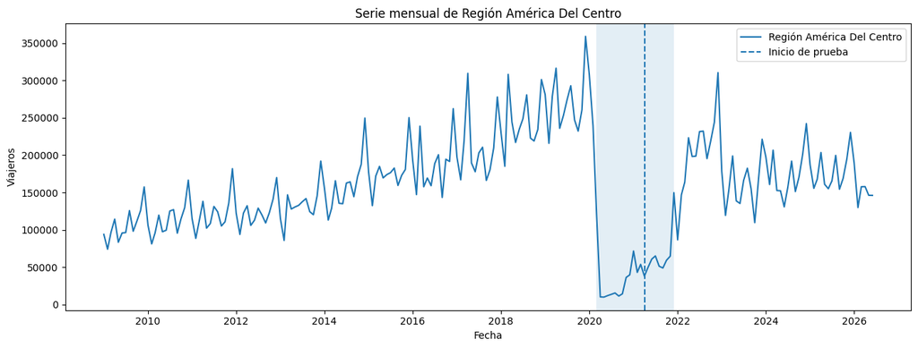

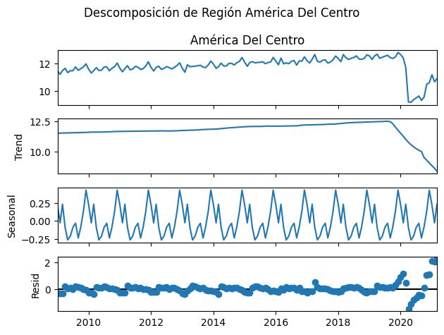

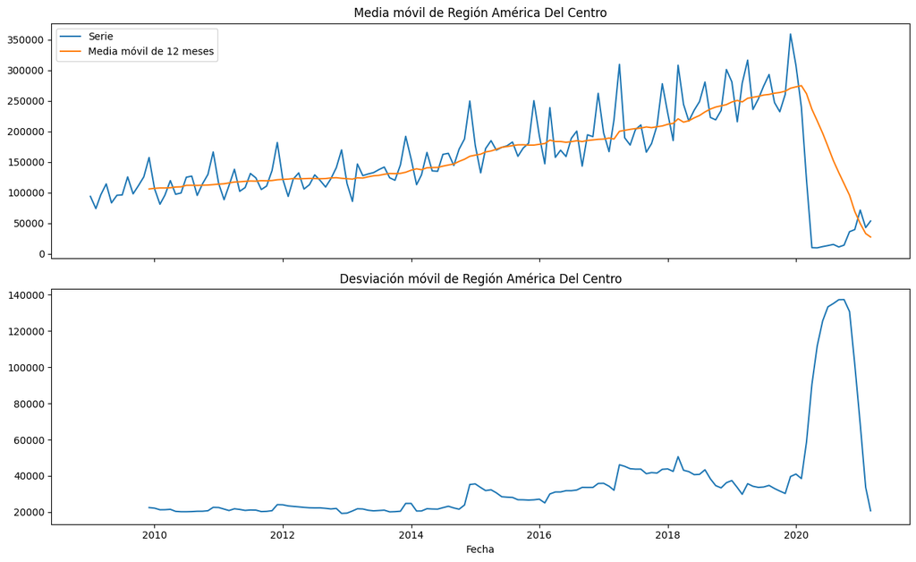

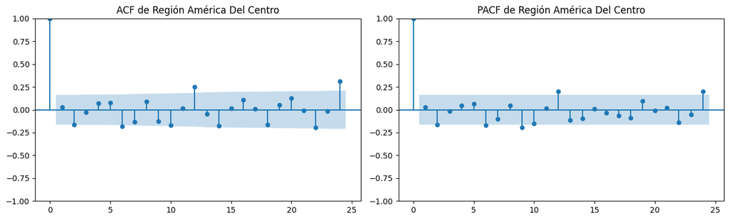

```
Inicio: 2009-01
Fin: 2026-06
Frecuencia: mensual con doce observaciones por año
Fuerza estacional: 0.180
Fuerza de tendencia: 0.578
Lambda Box Cox: 0.816
Valor sugerido de d: 1
Valor sugerido de D: 0
Valor inicial de p: 2
Valor inicial de q: 2
```

|  | Transformación | p valor ADF | Conclusión |
| --- | --- | --- | --- |
| 0 | Original | 0.213 | No estacionaria en media |
| 1 | Logaritmo | 0.200 | No estacionaria en media |
| 2 | Primera diferencia | 0.036 | Estacionaria en media |
| 3 | Diferencia estacional | 0.972 | No estacionaria en media |
| 4 | Primera diferencia y diferencia estacional | 0.000 | Estacionaria en media |

```
La serie no es estacionaria en media y necesita diferenciación.
La estacionalidad es débil y se probarán modelos con menor parte estacional.
==========================================================================================
Región América Del Norte
==========================================================================================
```

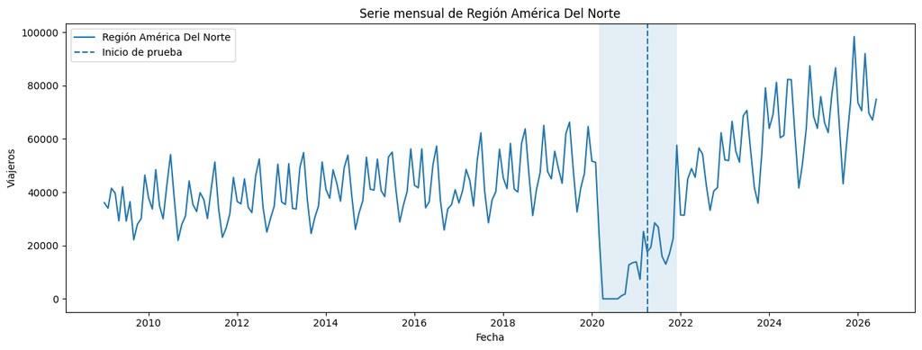